# 28_09_Homework_datavis_R

Porolo Viktoria

2024-09-28

```r
hogwarts <- read_csv("data/hogwarts_2024.csv")
hogwarts |> head()
```

```
## # A tibble: 6 × 60
##      id house    course sex   wandCore bloodStatus result Defence against the …¹
##   <dbl> <chr>     <dbl> <chr> <chr>    <chr>        <dbl>                  <dbl>
## 1     1 Ravencl…      4 fema… unicorn… half-blood      94                     73
## 2     2 Hufflep…      5 male  phoenix… half-blood      33                     38
## 3     3 Ravencl…      4 fema… dragon … half-blood     137                     52
## 4     4 Hufflep…      2 male  phoenix… half-blood      27                     50
## 5     5 Hufflep…      2 fema… phoenix… half-blood      67                     47
## 6     6 Gryffin…      6 male  phoenix… muggle-born    126                     44
## # ℹ abbreviated name: ¹`Defence against the dark arts exam`
## # ℹ 52 more variables: `Flying exam` <dbl>, `Astronomy exam` <dbl>,
## #   `Herbology exam` <dbl>, `Divinations exam` <dbl>, `Charms exam` <dbl>,
## #   `History of magic exam` <dbl>, `Arithmancy exam` <dbl>,
## #   `Care of magical creatures exam` <dbl>, `Muggle studies exam` <dbl>,
## #   `Study of ancient runes exam` <dbl>, `Transfiguration exam` <dbl>,
## #   `Potions exam` <dbl>, week_1 <dbl>, week_2 <dbl>, week_3 <dbl>, …
```

### Checking dataset structure

```r
hogwarts |> glimpse()
```

```
## Rows: 560
## Columns: 60
## $ id                                   <dbl> 1, 2, 3, 4, 5, 6, 7, 8, 9, 10, 11…
## $ house                                <chr> "Ravenclaw", "Hufflepuff", "Raven…
## $ course                               <dbl> 4, 5, 4, 2, 2, 6, 7, 5, 2, 3, 7, …
## $ sex                                  <chr> "female", "male", "female", "male…
## $ wandCore                             <chr> "unicorn hair", "phoenix feather"…
## $ bloodStatus                          <chr> "half-blood", "half-blood", "half…
## $ result                               <dbl> 94, 33, 137, 27, 67, 126, 63, 7, …
## $ `Defence against the dark arts exam` <dbl> 73, 38, 52, 50, 47, 44, 51, 47, 2…
## $ `Flying exam`                        <dbl> 33, 36, 73, 42, 41, 52, 34, 34, 2…
## $ `Astronomy exam`                     <dbl> 57, 45, 66, 49, 57, 59, 58, 37, 5…
## $ `Herbology exam`                     <dbl> 73, 50, 62, 39, 38, 46, 59, 23, 2…
## $ `Divinations exam`                   <dbl> 66, 54, 72, 42, 47, 49, 42, 38, 1…
## $ `Charms exam`                        <dbl> 60, 70, 77, 46, 35, 55, 86, 20, 4…
```

[output cut: 47 more lines]

```r
# Changing some variables type to factors
hogwarts <- hogwarts |> mutate(
  across(c(house, course, sex, wandCore, bloodStatus), ~ as.factor(.x))
)
```

## 1) Столбчатые диаграммы

1. Постройте барплот (столбчатую диаграмму), отражающую распределение числа студентов по курсу обучения. Примените любую из встроенных тем ggplot. Раскрасьте столбики любым понравившимся вам цветом (можно использовать как словесные обозначения, так и гекскоды). Добавьте цвет контура столбиков. (1 б).
2. Создайте новый барплот, отражающий распределение числа студентов по факультету. Добавьте на график вторую факторную переменную – происхождение (bloodStatus). Модифицируйте при помощи аргумента position графика так, чтобы каждый столбец показывал распределение факультета по чистоте крови в долях. Примените произвольную тему. Запишите текстом в rmd-документе, какой вывод можно сделать из графика? (1 б).
3. Модифицируйте датасет таким образом, чтобы в нем остались только чистокровные (pure-blood) и маглорожденные студенты (muggle-born). Создайте на основе этих данных график из пункта 2. Добавьте горизонтальную пунктирную линию произвольного цвета на уровне 50%. Дайте осям название на русском языке (1б). Дополнительно: переименуйте на русский язык категории легенды pure-blood и muggle-born (0.5 б).

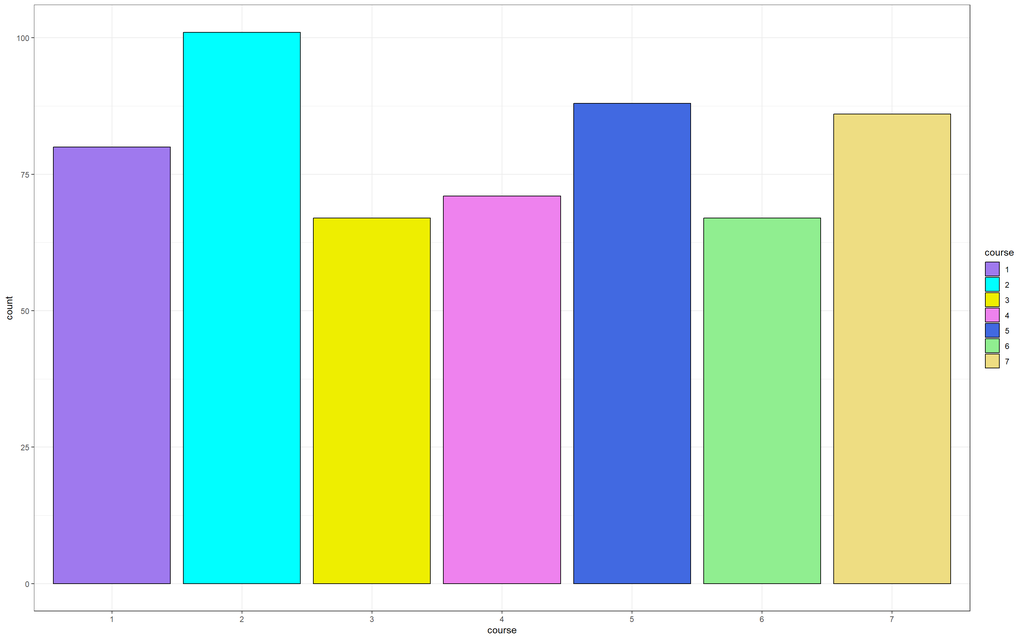

```r
ggplot(hogwarts)+
  geom_bar(aes(x = course,
               fill = course),
           colour = "black")+
  scale_fill_manual(values = c("1" = "mediumpurple2",
                               "2" = "cyan1",
                               "3" = "yellow2",
                               "4" = "violet",
                               "5" = "royalblue",
                               "6" = "lightgreen",
                               "7" = "lightgoldenrod"))+
  theme_bw()
```

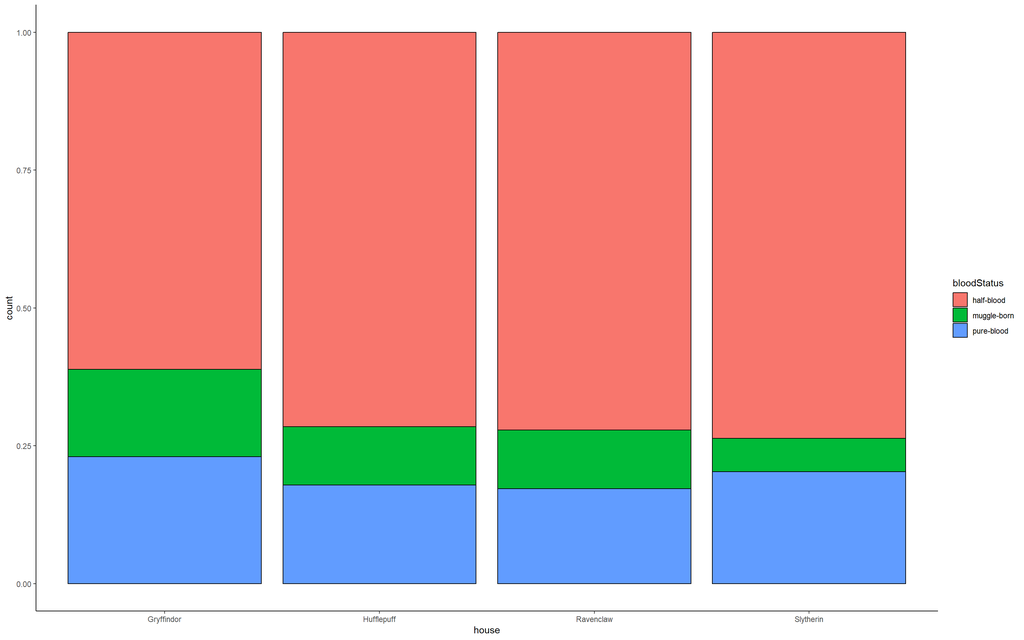

```r
ggplot(data = hogwarts, aes(x = house, fill = bloodStatus)) +
  geom_bar(position = "fill", color = "black") +
  theme_classic()
```

[figure not shown]

```r
hogwarts_filtered <- hogwarts %>%
  filter(bloodStatus %in% c("pure-blood", "muggle-born"))

ggplot(data = hogwarts_filtered, aes(x = house, fill = bloodStatus)) +
  geom_bar(position = "fill", color = "black") +
  geom_hline(yintercept = 0.5, linetype = "dashed", color = "cyan") +
  theme_light() +
  scale_fill_manual(values = c("pure-blood" = "slateblue", "muggle-born" = "peachpuff"),
                    labels = c("Чистокровные", "Маглорожденные"))
```

## 2) Боксплоты

1. Отобразите распределение баллов, заработанных студентами на 3-й неделе обучения, по факультетам. Отсортируйте факультеты в порядке убывания медианного балла за 3-ю неделю (мы не останавливались на этом в лекции, но упомянутая в ней функция по умолчанию сортирует именно по медиане, так что в этом случае дополнительных аргументов передавать не следует). (1 б.)
2. Добавьте отображение разными цветами для происхождения студентов (bloodStatus). Добавьте на боксплот вырезку (notch). Настройте для данного чанка размер изображения 14:14 дюймов. Приведите названия осей к корректному виду. (1 б.)
3. Добавьте на график джиттер-плот. Удалите отображение выбросов у боксплота. Видоизмените по своему вкусу толщину линий и ширину боксплота. (1 б.) Дополнительно: Добавьте название графика и подпись (0.5 б.)

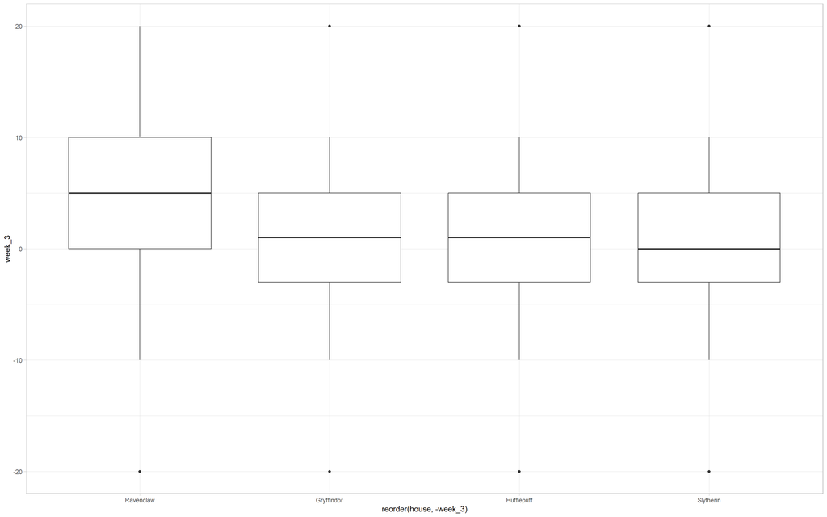

```r
ggplot(hogwarts)+
  geom_boxplot(aes(x = reorder(house, -week_3),
                    y = week_3)) +
  theme_light()
```

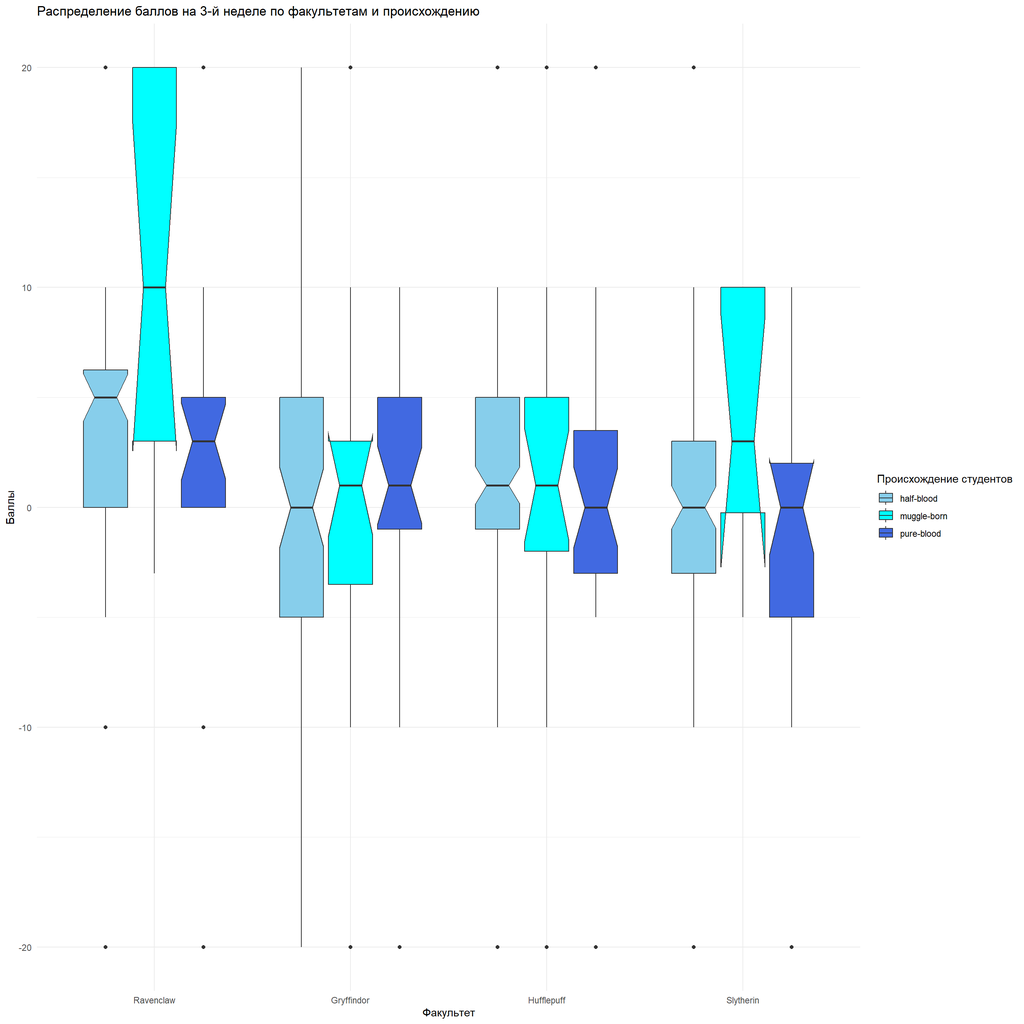

```r
ggplot(hogwarts)+
  geom_boxplot(aes(x = reorder(house, -week_3),
                    y = week_3, fill = bloodStatus),
               notch = TRUE) +
  theme_minimal() +
  labs(title = "Распределение баллов на 3-й неделе по факультетам и происхождению",
       x = "Факультет",
       y = "Баллы",
       fill = "Происхождение студентов") +
  scale_fill_manual(values = c("pure-blood" = "royalblue", "muggle-born" = "cyan", "half-blood" = "skyblue"))
```

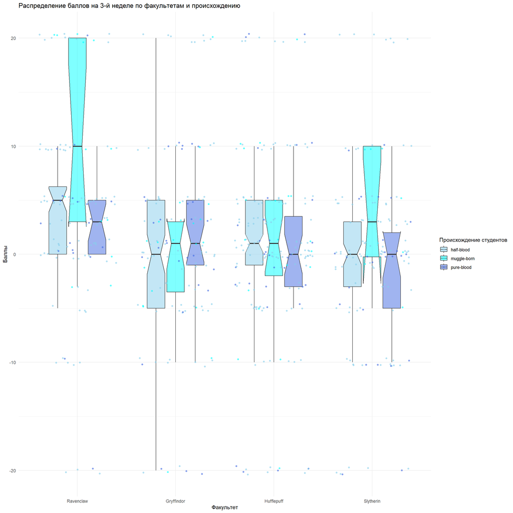

```r
ggplot(hogwarts) +
  geom_boxplot(aes(x = reorder(house, -week_3),
                   y = week_3, fill = bloodStatus),
               notch = TRUE, outlier.shape = NA,
               alpha = 0.5,
               linewidth = 0.5,
               width = 0.6) +
  geom_jitter(aes(x = reorder(house, -week_3),
                  y = week_3,
                  color = bloodStatus),
              size = 1.2, alpha = 0.6) +
  theme_minimal() +
  labs(title = "Распределение баллов на 3-й неделе по факультетам и происхождению",
       x = "Факультет",
       y = "Баллы",
       fill = "Происхождение студентов",
       color = "Происхождение студентов") +
  scale_fill_manual(values = c("pure-blood" = "royalblue",
                                "muggle-born" = "cyan",
                                "half-blood" = "skyblue")) +
  scale_color_manual(values = c("pure-blood" = "royalblue",
                                 "muggle-born" = "cyan",
                                 "half-blood" = "skyblue"))
```

## 3) Разное

1. Постройте “леденцовый график” (lollipop-plot) для количества набранных студентами 5-го курса баллов за весь учебный год (по оси ординат – id студента, по оси абсцисс – итоговый балл). Отсортируйте студентов в порядке убывания итогового балла. Раскрасьте точки на “леденцах” в зависимости от сердцевины волшебной палочки. Палочки с сердечной жилой дракона должны быть красного цвета, с пером феникса – желтого, с волосом единорога – серого. (1 б.)
2. Постройте гистограмму распредления баллов за экзамен по астрономии. Выделите цветом факультет Слизерин. Примените 18-й кегль к тексту на осях x, y и легенды. Название оси y и легенды запишите 20-м кеглем, оси x – 22-м. Измените название оси y на “Number of students”. (1 б.)
3. На лекции мы использовали комбинацию theme_bw(), и созданной нами theme_custom, чтобы одновременно сделать фон белым и увеличить шрифт. Модифицируйте theme_custom таким образом, чтобы она и выполняла свои прежние функции, и делала фон белым без помощи theme_bw(). Примените новую кастомную тему к графику, полученному в последнем пункте блока по боксплотам (1.5 б).

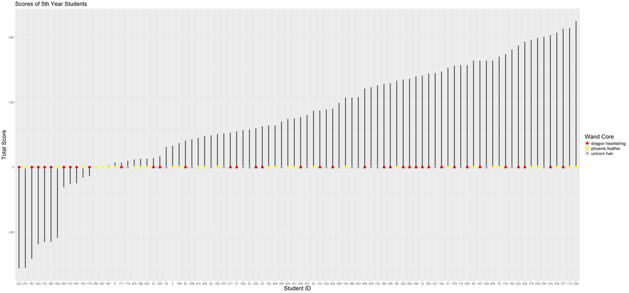

```r
lollipop_data <- hogwarts %>%
  filter(course == 5) %>%
  arrange(desc(result))

ggplot(lollipop_data, aes(x = reorder(id, result),
                          xend = reorder(id, result),
                          y = 0,
                          yend = result,
                           color = wandCore)) +
  geom_segment(aes(x = reorder(id, result),
                          xend = reorder(id, result),
                          y = 0,
                          yend = result),
               size = 1.5, color = "grey30") +
  geom_point(size = 4) +
  scale_color_manual(values = c("dragon heartstring" = "red",
                                 "phoenix feather" = "yellow",
                                 "unicorn hair" = "grey70")) +
  labs(title = "Scores of 5th Year Students",
       x = "Student ID",
       y = "Total Score",
       color = "Wand Core") +
theme(
    plot.title = element_text(size = 20),
    plot.subtitle = element_text(size = 20, hjust = 0.5),
    strip.text = element_text(size = 15),
    axis.text = element_text(size = 10),
    axis.title = element_text(size = 20),
    legend.title = element_text(size = 20),
    legend.text = element_text(size = 15)
  )
```

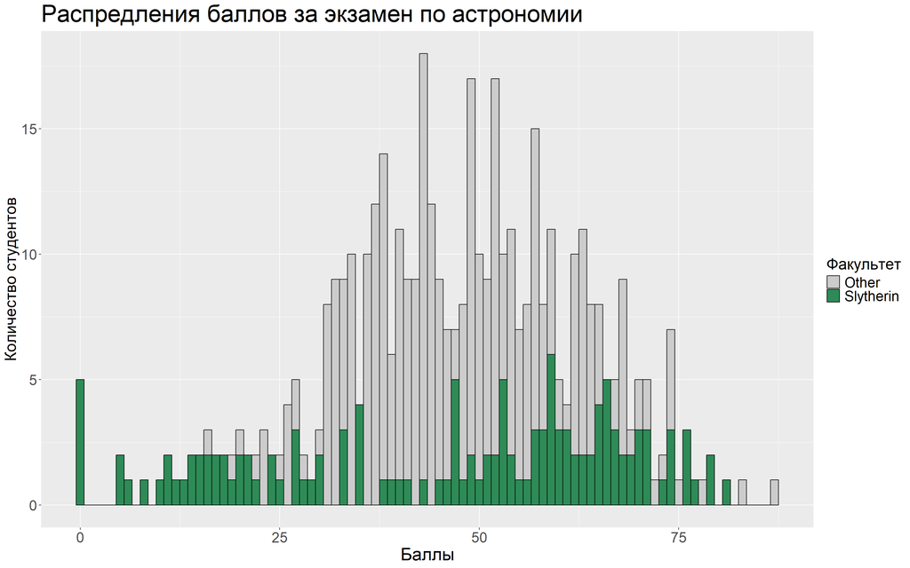

```r
ggplot(hogwarts, aes(x = `Astronomy exam`, fill = ifelse(house == "Slytherin", "Slytherin", "Other"))) +
  geom_histogram(binwidth = 1, color = "black", position = "identity") +
  scale_fill_manual(values = c("Slytherin" = "seagreen", "Other" = "grey80")) +
  labs(title = "Распредления баллов за экзамен по астрономии",
       x = "Баллы",
       y = "Количество студентов",
       fill = "Факультет") +
 theme(axis.title.x = element_text(size = 22),
        axis.title.y = element_text(size = 20),
        legend.title = element_text(size = 20),
        axis.text = element_text(size = 18),
        legend.text = element_text(size = 18),
       plot.title = element_text(size = 30))
```

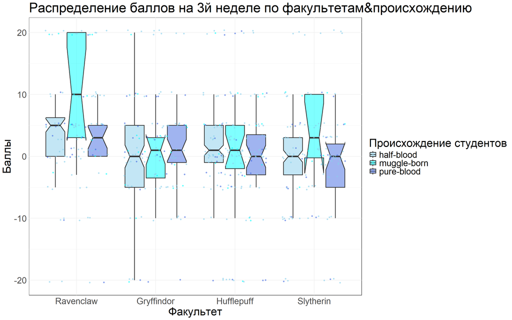

```r
theme_custom <- theme(
    panel.background = element_rect(fill = "white"),
    plot.title = element_text(size = 30),
    plot.subtitle = element_text(size = 25, hjust = 0.5),
    strip.text = element_text(size = 20),
    axis.text = element_text(size = 20),
    axis.title = element_text(size = 25),
    legend.title = element_text(size = 25),
    legend.text = element_text(size = 20)
  )

ggplot(hogwarts) +
  geom_boxplot(aes(x = reorder(house, -week_3),
                   y = week_3, fill = bloodStatus),
               notch = TRUE, outlier.shape = NA,
               alpha = 0.5,
               linewidth = 0.8,
               width = 0.8) +
  geom_jitter(aes(x = reorder(house, -week_3),
                  y = week_3,
                  color = bloodStatus),
              size = 1.2, alpha = 0.6)+
  theme_minimal() +
  labs(title = "Распределение баллов на 3й неделе по факультетам&происхождению",
       x = "Факультет",
       y = "Баллы",
       fill = "Происхождение студентов",
       color = "Происхождение студентов") +
  scale_fill_manual(values = c("pure-blood" = "royalblue",
                                "muggle-born" = "cyan",
                                "half-blood" = "skyblue")) +
  scale_color_manual(values = c("pure-blood" = "royalblue",
                                 "muggle-born" = "cyan",
                                 "half-blood" = "skyblue")) +
  theme_custom
```

## 4) Фасетирование

1. Напишите, какой, по вашему мнению, способ фасетирования (по строкам или по столбцам) лучше использовать для визуализации гистограммы. Почему? А какой для визуализации violin-plot? Почему? Можно ли вывести общее правило? (1.5 б)
2. Постройте гистограмму для результата любого выбранного вами экзамена, кроме зельеварения. Настройте оптимальное на ваш взгляд число столбцов гистограммы. Выполните фасетирование по курсу. Постарайтесь, чтобы график был по возможности компактным. (1 б.).
3. Отобразите на одном графике распределение плотности вероятности для оценки студентов на экзамене по защите от темных искусств и на экзамене по травологии. Раскрасьте их в любые выбранные вами цвета, постарайтесь, чтобы оба распределения отображались целиком. Примените тему из 3-го пункта блока “Разное”. Сделайте фасетирование по полу (1 б.).

**4.1**

Гистограмма: Лучше делать фасетирование по строкам. Это помогает легче воспринимать информацию и сравнивать распределение данных по разным уровням, особенно когда вертикальные шкалы разные. Такой подход делает графики более компактными и удобными.

Violin-plot: В этом случае лучше использовать фасетирование по столбцам. Violin-plot показывает, как распределены данные, и когда диаграммы располагаются рядом, их проще сравнивать. Общая вертикальная шкала помогает лучше увидеть различия между группами.

Общее правило:

- Если данные имеют разные вертикальные масштабы, лучше использовать фасетирование по строкам, чтобы было легче читать графики.
- Если масштабы схожи, фасетирование по столбцам поможет лучше сравнить разные группы.

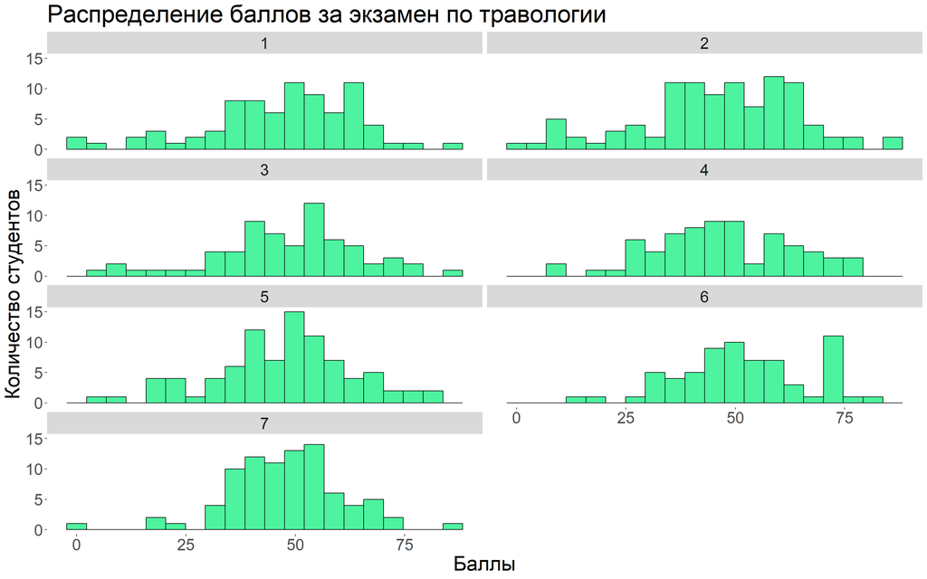

```r
num_bins <- 20  # Настройка количества столбцов


ggplot(hogwarts, aes(x = `Herbology exam`)) +
  geom_histogram(bins = num_bins, fill = "springgreen2", color = "black", alpha = 0.7) +
  labs(title = "Распределение баллов за экзамен по травологии",
       x = "Баллы",
       y = "Количество студентов") +
  facet_wrap(~ course, ncol = 2) +
  theme_custom
```

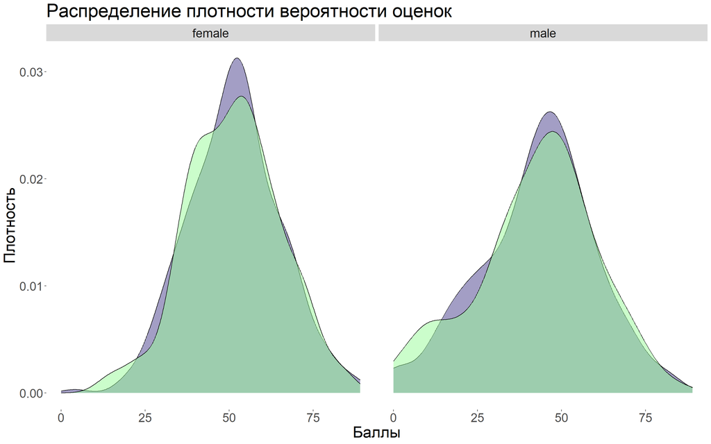

```r
ggplot(hogwarts) +
  geom_density(aes(x = `Defence against the dark arts exam`, fill = "Защита от темных искусств"),
               alpha = 0.5, color = 'black', fill = "darkslateblue") +
  geom_density(aes(x = `Herbology exam`, fill = "Травология"),
               alpha = 0.5, color = 'black', fill = "palegreen") +
  labs(title = "Распределение плотности вероятности оценок",
       x = "Баллы",
       y = "Плотность") +
  scale_fill_manual(values = c("darkslateblue", "palegreen"),
                    labels = c("Защита от темных искусств", "Травология")) +
  facet_wrap(~ sex) +
  theme_custom
```